# Tutorial: Real Data and Expensive Code

The last tutorial illustrate how to apply the developed package to the real data set. It also shows how to use the emulator in the case of expensive code. For this purpose, we need to

- fit Gaussian process to the simulated data;
- use the fitted Gaussian process as emulator and as a surrogate for the computer model;
- fit the RKHS calibration model.

```r
library(calibration)
source("./code/core/loadAll.R")
```

Let’s load the data set and plot the actual observations.

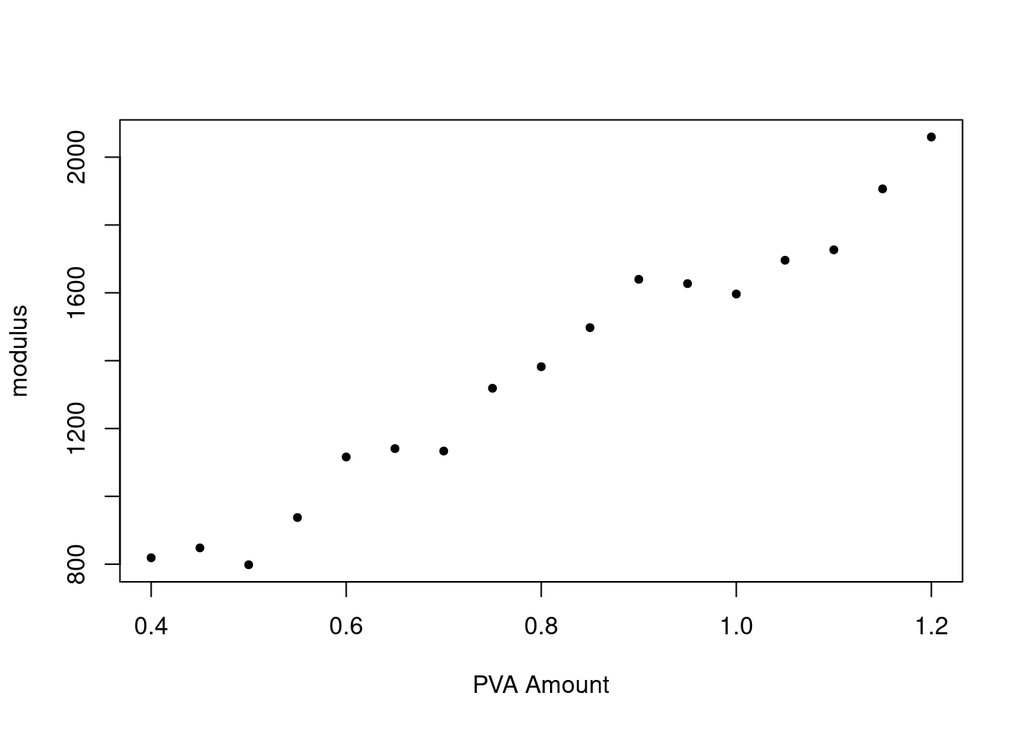

```r
mData = R.matlab::readMat("./data/data_new_Phy_Sim.mat")
real_x = mData$xa
real_yp_original = mData$PA
plot(real_x, real_yp_original, pch = 20, xlab = "PVA Amount", ylab = "modulus")
```

```r
lowerB = 0.4
upperB = 1.2
nSample = length(real_x)
real_x = matrix(real_x, nSample)
predX = matrix(seq(lowerB, upperB, length.out = 100), nrow =100)
linkLowerB = 0.35
linkUpperB = 1.05
```

```r
emu_x = mData$PVA.a[,1]
emu_theta = mData$PVA.a[,2]
emu_y = mData$A.502[,2]
emuData = list(x = cbind(emu_x, emu_theta), y = emu_y)
```

### Fitting Gaussian Process for the enumlator

The Gaussian process uses the squared exponential kernel
$$k(x_1, x_2) = \theta_1 \exp\left(- \Vert x_1 - x_2 \Vert_2^2/\theta_2\right).$$
The kernel parameters are ensured to be positive by taking the transformation
$$\theta_i = \exp(\beta_i),\ i = 1,2.$$

```r
GP = new(gaussianP)
GP$set_data(emuData$y, emuData$x)
betaInit = rnorm(2, c(2,-2), 2)
optRes = optim(betaInit, fn = GP$cv_obj,
               gr = GP$cv_grad, method = "Nelder-Mead",
               control = list(alpha = 0.01, trace = 1))
```

```
##   Nelder-Mead direct search function minimizer
## function value for initial parameters = 362918.191373
##   Scaled convergence tolerance is 0.0054079
## Stepsize computed as 0.368529
## BUILD              3 407086.940444 304481.341263
## LO-REDUCTION       5 362918.191373 304481.341263
## LO-REDUCTION       7 331435.507852 304481.341263
## LO-REDUCTION       9 317198.166146 304481.341263
## LO-REDUCTION      11 310565.073166 304481.341263
## LO-REDUCTION      13 307410.766091 304481.341263
## LO-REDUCTION      15 305896.230335 304481.341263
## LO-REDUCTION      17 305165.719091 304481.341263
## LO-REDUCTION      19 304812.605107 304481.341263
## LO-REDUCTION      21 304641.739329 304481.341263
## LO-REDUCTION      23 304559.018771 304481.341263
## LO-REDUCTION      25 304518.961873 304481.341263
## LO-REDUCTION      27 304499.562297 304481.341263
## LO-REDUCTION      29 304490.166539 304481.341263
## LO-REDUCTION      31 304485.615784 304481.341263
## LO-REDUCTION      33 304483.411635 304481.341263
## LO-REDUCTION      35 304482.344054 304481.341263
## LO-REDUCTION      37 304481.826968 304481.341263
## LO-REDUCTION      39 304481.576516 304481.341263
## LO-REDUCTION      41 304481.455208 304481.341263
## LO-REDUCTION      43 304481.396453 304481.341263
## LO-REDUCTION      45 304481.367994 304481.341263
## LO-REDUCTION      47 304481.354210 304481.341263
## LO-REDUCTION      49 304481.347534 304481.341263
## Exiting from Nelder Mead minimizer
##     51 function evaluations used
```

```r
optRes$value/1e5
```

```
## [1] 3.044813
```

```r
optRes$par
```

```
## [1] -3.316760 -1.325744
```

The last line prints the fitted value of $\beta_1$ and $\beta_2$. We need to repeat the above fitting multiple times with random initial values and take the value of $\beta_1$ and $\beta_2$ with minimal objective value `optRes$value`. In fact, `optRes$value` is the leave-one-out cross-validation error. In the following, we will take the following specific values of $\beta_1$ and $\beta_2$.

```r
emu_betaOpt = c(3.932682, -2.6915)
```

### Debias

Subtract the bias between two datasets (the actual observation and the emulator training dataset).

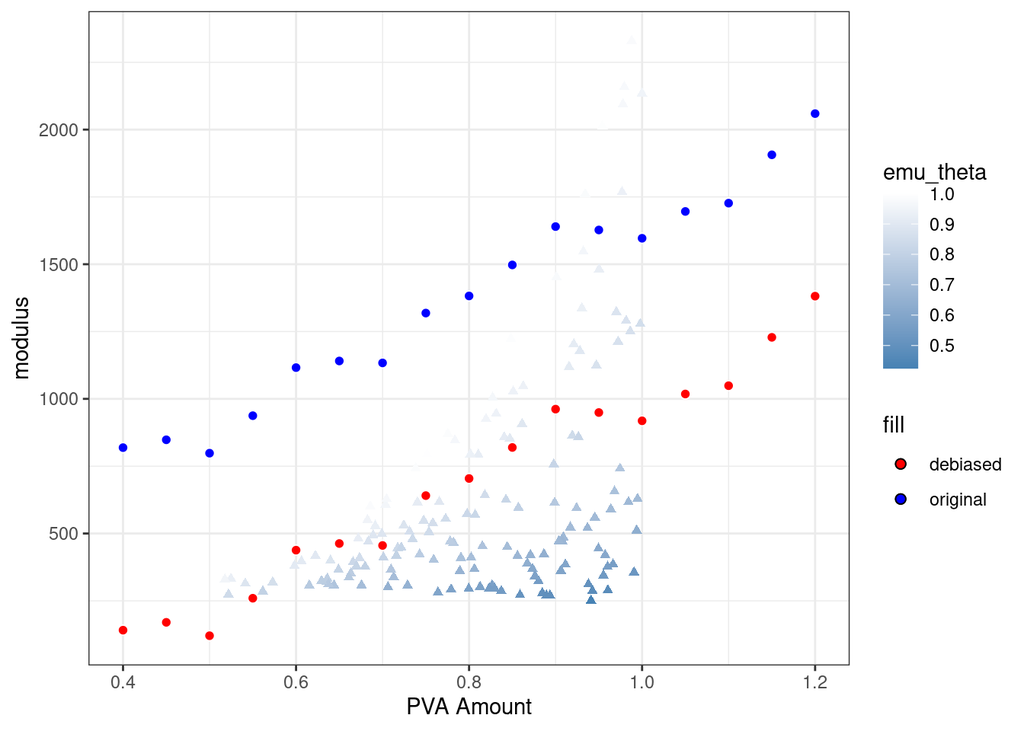

```r
### Debias and plot
sel = real_x > 0.5 & real_x < 1.0
bias = mean(emu_y) - mean(real_yp_original[sel])
real_yp = real_yp_original + bias
library(ggplot2)
emu_data = data.frame(emu_x = emu_x, emu_y = emu_y, emu_theta = emu_theta)
real_data = data.frame(real_x = real_x, real_yp = real_yp, emu_theta = 1)
real_data2 = data.frame(real_x = real_x, real_yp = real_yp_original, emu_theta = 1)
ggplot(emu_data, aes(x = emu_x, y = emu_y, color = emu_theta)) + geom_point(shape = 17) +
    geom_point(aes(real_x, real_yp, fill = "debiased"), pch = 21,data = real_data,size = 2) +
    geom_point(aes(real_x, real_yp, fill = "original"), pch = 21,data = real_data2,size = 2) +
    scale_color_gradient(low="steelblue",high="white")+
    theme_bw() + xlab("PVA Amount") + ylab("modulus")+
    scale_fill_manual(values=c("red", "blue","blue"))
```

### Fitting the model

**Note:** Setting `problemIndex=0` means using Gaussian process as a surrogate for the computer model in the expensive code case.

```r
lambdaSeqCubic = exp(seq(-4,4,length.out = 25))
r1Obj = create_CalibrationObj(problemIndex = 0,
                              thetaIndex = 5,
                              linkIndex = 2,
                              numComp = 1,
                              emuData = emuData,
                              betaOpt = emu_betaOpt,
                              linkLowerB = linkLowerB, linkUpperB = linkUpperB)
real_x = matrix(real_x, nrow = nSample)
r1Obj$setData(real_yp, real_x,  lowerB, upperB)
getInitGamma = function(nSample){
    gammaInit = rnorm(nSample + 2, mean = 0, sd = 10)
    return(gammaInit)
}
result = selectLambdaGCV(r1Obj, lambdaSeqCubic,
                         nSample,
                         getInitGamma, predX,
                         linkLowerB, linkUpperB)
yFitted = r1Obj$predict_y(result$gammaOpt, predX, TRUE)
```

The next plot is the fitted response.

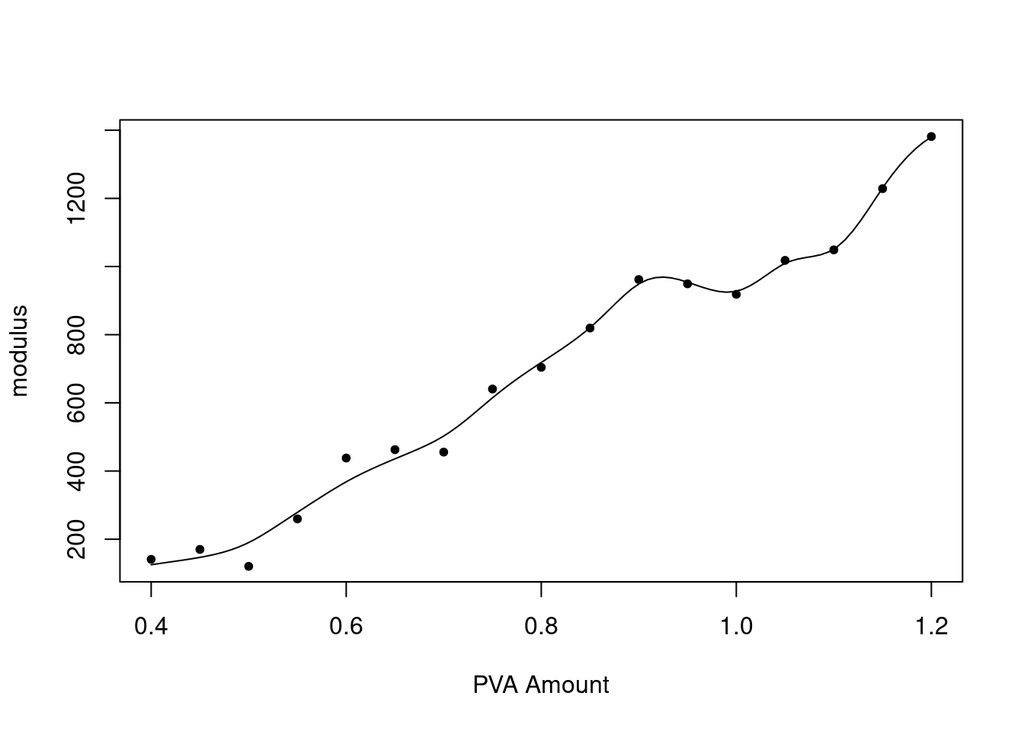

```r
plot(predX, yFitted[,1], type = "l", xlab = "PVA Amount", ylab = "modulus")
points(real_x, real_yp,pch = 20)
```

The next plot is the fitted calibration function.

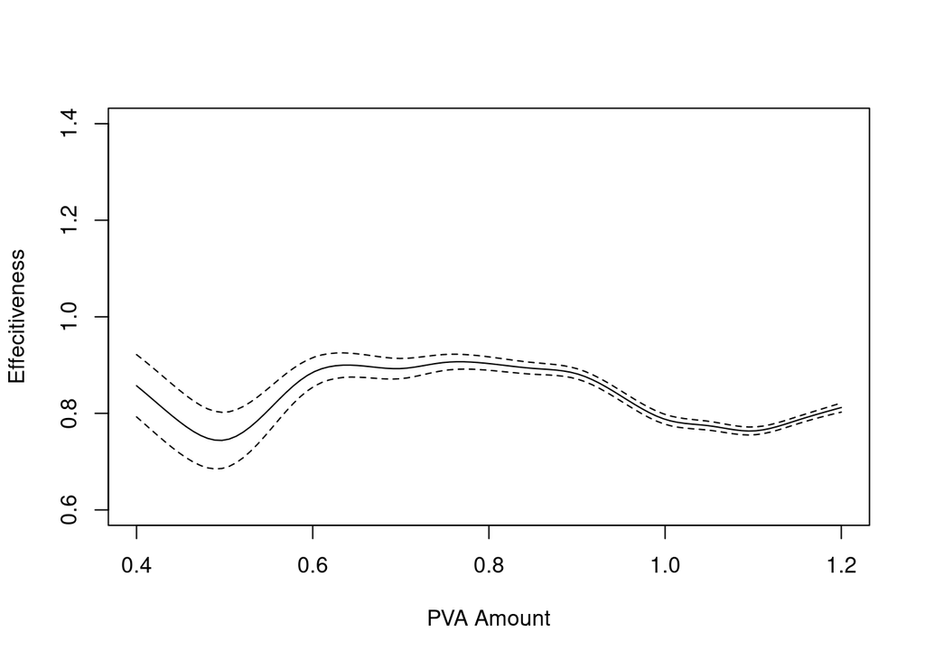

```r
plot(predX, yFitted[,3], type = "l",ylim = c(0.6,1.4),
     xlab = "PVA Amount", ylab = "Effecitiveness")
lines(predX, yFitted[,3] + yFitted[,4], lty = 2)
lines(predX, yFitted[,3] - yFitted[,4], lty = 2)
```